# day10-4

```python
%matplotlib inline
import pandas as pd
```

```python
titles = pd.read_csv('titles.csv')
titles.head()
```

|  | title | year |
| --- | --- | --- |
| 0 | Tasveer Mere Sanam | 1996 |
| 1 | Only You | 1994 |
| 2 | El pueblo del terror | 1970 |
| 3 | Machine | 2007 |
| 4 | MARy | 2008 |

```python
cast = pd.read_csv('cast.csv', index_col=None)
cast.head()
```

|  | title | year | name | type | character | n |
| --- | --- | --- | --- | --- | --- | --- |
| 0 | Closet Monster | 2015 | Buffy #1 | actor | Buffy 4 | 31.0 |
| 1 | Suuri illusioni | 1985 | Homo $ | actor | Guests | 22.0 |
| 2 | Battle of the Sexes | 2017 | $hutter | actor | Bobby Riggs Fan | 10.0 |
| 3 | Secret in Their Eyes | 2015 | $hutter | actor | 2002 Dodger Fan | NaN |
| 4 | Steve Jobs | 2015 | $hutter | actor | 1988 Opera House Patron | NaN |

# Define a year as a "Superman year" whose films feature more Superman characters than Batman. How many years in film history have been Superman years?

```python
superman_years = cast[cast['character'].str.contains('Superman|Batman')]
superman_vs_batman = superman_years.groupby('year')['character'].value_counts().unstack()
superman_years_count = (superman_vs_batman['Superman'] > superman_vs_batman['Batman']).sum()

print(f"The number of years in film history that have been 'Superman years' is {superman_years_count}.")
```

```
The number of years in film history that have been 'Superman years' is 1.
```

# How many years have been "Batman years", with more Batman characters than Superman characters?

```python
batman_years = cast[cast['character'].str.contains('Superman|Batman')]
batman_vs_superman = batman_years.groupby('year')['character'].value_counts().unstack()
batman_years_count = (batman_vs_superman['Batman'] > batman_vs_superman['Superman']).sum()

print(f"The number of years in film history that have been 'Batman years' is {batman_years_count}.")
```

```
The number of years in film history that have been 'Batman years' is 11.
```

# Plot the number of actor roles each year and the number of actress roles each year over the history of film.

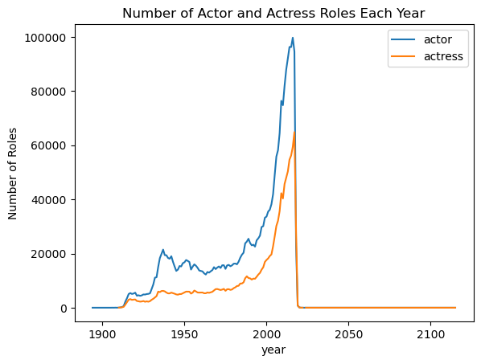

```python
import matplotlib.pyplot as plt

actor_actress_roles = cast[cast['type'].isin(['actor', 'actress'])]
roles_per_year = actor_actress_roles.groupby(['year', 'type']).size().unstack()


roles_per_year.plot(kind='line')
plt.xlabel('year')
plt.ylabel('Number of Roles')
plt.title('Number of Actor and Actress Roles Each Year')
plt.legend(['actor', 'actress'])
plt.show()
```

# Plot the number of actor roles each year and the number of actress roles each year, but this time as a kind='area' plot.

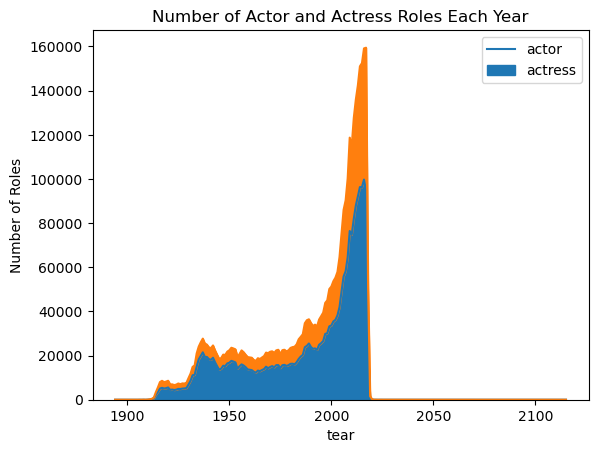

```python
actor_actress_roles = cast[cast['type'].isin(['actor', 'actress'])]
roles_per_year = actor_actress_roles.groupby(['year', 'type']).size().unstack()

roles_per_year.plot(kind='area')
plt.xlabel('tear')
plt.ylabel('Number of Roles')
plt.title('Number of Actor and Actress Roles Each Year')
plt.legend(['actor', 'actress'])
plt.show()
```

# Plot the difference between the number of actor roles each year and the number of actress roles each year over the history of film.

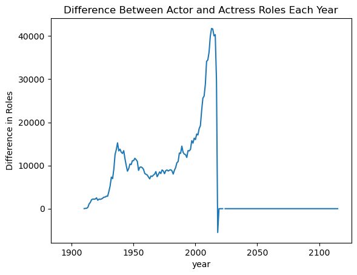

```python
actor_actress_roles = cast[cast['type'].isin(['actor', 'actress'])]
roles_per_year = actor_actress_roles.groupby(['year', 'type']).size().unstack()

roles_per_year['Difference'] = roles_per_year['actor'] - roles_per_year['actress']

roles_per_year['Difference'].plot(kind='line')
plt.xlabel('year')
plt.ylabel('Difference in Roles')
plt.title('Difference Between Actor and Actress Roles Each Year')
plt.show()
```

# Plot the fraction of roles that have been 'actor' roles each year in the history of film.

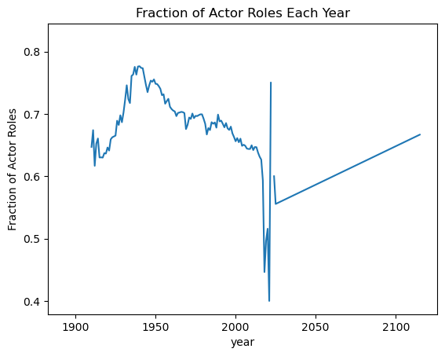

```python
actor_actress_roles = cast[cast['type'].isin(['actor', 'actress'])]
roles_per_year = actor_actress_roles.groupby(['year', 'type']).size().unstack()

roles_per_year['Fraction of actor Roles'] = roles_per_year['actor'] / (roles_per_year['actor'] + roles_per_year['actress'])

roles_per_year['Fraction of actor Roles'].plot(kind='line')
plt.xlabel('year')
plt.ylabel('Fraction of Actor Roles')
plt.title('Fraction of Actor Roles Each Year')
plt.show()
```

# Plot the fraction of supporting (n=2) roles that have been 'actor' roles each year in the history of film.

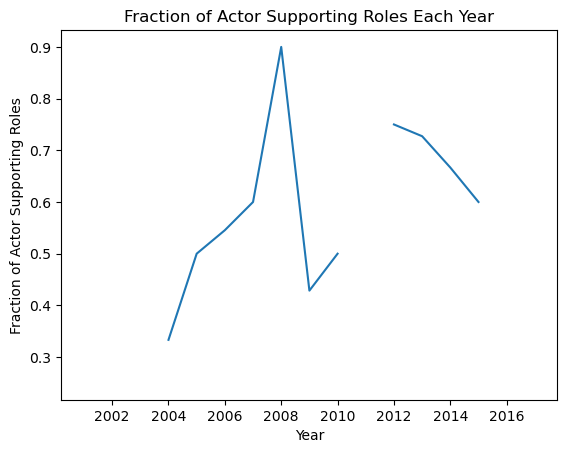

```python
actor_actress_roles = cast[cast['type'].isin(['actor', 'actress'])]
supporting_roles = actor_actress_roles[actor_actress_roles['character'] == 'Supporting']
roles_per_year = supporting_roles.groupby(['year', 'type']).size().unstack()

roles_per_year['Fraction of actor Supporting Roles'] = roles_per_year['actor'] / (roles_per_year['actor'] + roles_per_year['actress'])

roles_per_year['Fraction of actor Supporting Roles'].plot(kind='line')
plt.xlabel('Year')
plt.ylabel('Fraction of Actor Supporting Roles')
plt.title('Fraction of Actor Supporting Roles Each Year')
plt.show()
```

# Build a plot with a line for each rank n=1 through n=3, where the line shows what fraction of that rank's roles were 'actor' roles for each year in the history of film.

```python
actor_actress_roles = cast[cast['type'].isin(['actor', 'actress'])]
roles_per_year_rank = actor_actress_roles.groupby(['year', 'Rank', 'type']).size().unstack()

for n in range(1, 4):
    roles_per_year_rank[f'Fraction of actor Roles (Rank {n})'] = roles_per_year_rank[f'actor (Rank {n})'] / (roles_per_year_rank[f'actor (Rank {n})'] + roles_per_year_rank[f'actress (Rank {n})'])

for n in range(1, 4):
    roles_per_year_rank[f'Fraction of actor Roles (Rank {n})'].plot(kind='line')

plt.xlabel('Year')
plt.ylabel('Fraction of actor Roles')
plt.title('Fraction of actor Roles for Each Rank (n=1 to n=3) Each Year')
plt.legend()
plt.show()
```

[output not shown]